# 05_ProcessMining

Nils Gandlau

13 12 2019

## 1. Descriptive Analysis

#### a. How many cases (orders) does the event log contain?

We have 24,2120 unique cases/orders.

```r
length(unique(eventlog$order_id))
```

```
## [1] 24120
```

#### b. How many events does the event log contain?

```r
nrow(eventlog)
```

```
## [1] 144986
```

#### c. How many unique activities are executed throughout the process?

There are 6 unique activities:

1. purchase
2. approval
3. deliver_carrier
4. deliver_customer
5. sent out review survey to customer
6. customer provides review

```r
length(unique(eventlog$activity))
```

```
## [1] 6
```

#### d. Summary of event log and visualizations of interesting variables

```r
summary(eventlog)
```

```
## Number of events:  144986
## Number of cases:  24120
## Number of traces:  31
## Number of distinct activities:  6
## Average trace length:  6.011028
##
## Start eventlog:  NA
## End eventlog:  NA
```

```
##    order_id                                       activity
##  Length:144986      approve                           :24120
##  Class :character   customer provides review          :24253
##  Mode  :character   deliever_carrier                  :24120
##                     deliever_customer                 :24120
##                     purchase                          :24120
##                     sent out review survey to customer:24253
##
##    timestamp                    review_score       boleto
##  Min.   :2016-10-04 09:16:33   Min.   :1.000   Min.   :0.0000
##  1st Qu.:2017-09-21 12:09:55   1st Qu.:4.000   1st Qu.:0.0000
##  Median :2018-01-29 15:18:45   Median :5.000   Median :0.0000
##  Mean   :2018-01-09 08:40:18   Mean   :4.158   Mean   :0.1969
##  3rd Qu.:2018-05-10 23:30:58   3rd Qu.:5.000   3rd Qu.:0.0000
##  Max.   :2018-10-26 21:36:41   Max.   :5.000   Max.   :1.0000
##  NA's   :6
##   credit_card                               customer_id       debit_card
##  Min.   :0.0000   9e29cde4ddb42f9330bcf3c9bc23d177:    10   Min.   :0.00000
##  1st Qu.:1.0000   0033823ee55671ac5317d423291333c2:     8   1st Qu.:0.00000
##  Median :1.0000   060feb3bc91804b596b106fa63834799:     8   Median :0.00000
##  Mean   :0.7732   080f252f36da3da6eb5b04407af199f7:     8   Mean   :0.01528
##  3rd Qu.:1.0000   08a113f40963196742d5538a95776e34:     8   3rd Qu.:0.00000
##  Max.   :1.0000   090c8832aab02cc3a2a256a01b7c1068:     8   Max.   :1.00000
##                   (Other)                         :144936
##  nmb_pay_types    not_defined order_estimated_delivery_date total_installments
##  Min.   :1.000   Min.   :0    Min.   :2016-11-24 00:00:00   Min.   : 1.000
##  1st Qu.:1.000   1st Qu.:0    1st Qu.:2017-10-05 00:00:00   1st Qu.: 1.000
##  Median :1.000   Median :0    Median :2018-02-16 00:00:00   Median : 2.000
##  Mean   :1.022   Mean   :0    Mean   :2018-01-25 19:54:50   Mean   : 2.974
##  3rd Qu.:1.000   3rd Qu.:0    3rd Qu.:2018-05-28 00:00:00   3rd Qu.: 4.000
##  Max.   :2.000   Max.   :0    Max.   :2018-10-23 00:00:00   Max.   :25.000
##
##  total_pay_value      voucher        customer_state       nmb_items
##  Min.   :  10.07   Min.   :0.00000   Length:144986      Min.   : 1.000
##  1st Qu.:  61.78   1st Qu.:0.00000   Class :character   1st Qu.: 1.000
##  Median : 105.28   Median :0.00000   Mode  :character   Median : 1.000
##  Mean   : 158.49   Mean   :0.03646                      Mean   : 1.141
##  3rd Qu.: 176.16   3rd Qu.:0.00000                      3rd Qu.: 1.000
##  Max.   :4950.34   Max.   :1.00000                      Max.   :15.000
##
```

[output cut: 17 more lines]

```
##  Min.   :    0   Min.   :  7.00   Min.   :  2.00   Min.   :  7.00
##  1st Qu.:  300   1st Qu.: 18.00   1st Qu.:  8.00   1st Qu.: 15.00
##  Median :  700   Median : 25.00   Median : 13.00   Median : 20.00
##  Mean   : 2123   Mean   : 30.18   Mean   : 16.63   Mean   : 23.06
##  3rd Qu.: 1825   3rd Qu.: 38.00   3rd Qu.: 20.00   3rd Qu.: 30.00
##  Max.   :30000   Max.   :105.00   Max.   :105.00   Max.   :118.00
##  NA's   :12      NA's   :12       NA's   :12       NA's   :12
##       status       activity_instance      .order
##  complete:144986   Length:144986      Min.   :     1
##                    Class :character   1st Qu.: 36247
##                    Mode  :character   Median : 72494
##                                       Mean   : 72494
##                                       3rd Qu.:108740
##                                       Max.   :144986
##
```

## 2. Control-Flow Perspective

#### a)

According to the `summary()`-command, there are 31 traces in the event log.

#### b)

The most frequent variant of all traces covers almost 90% of the event log.

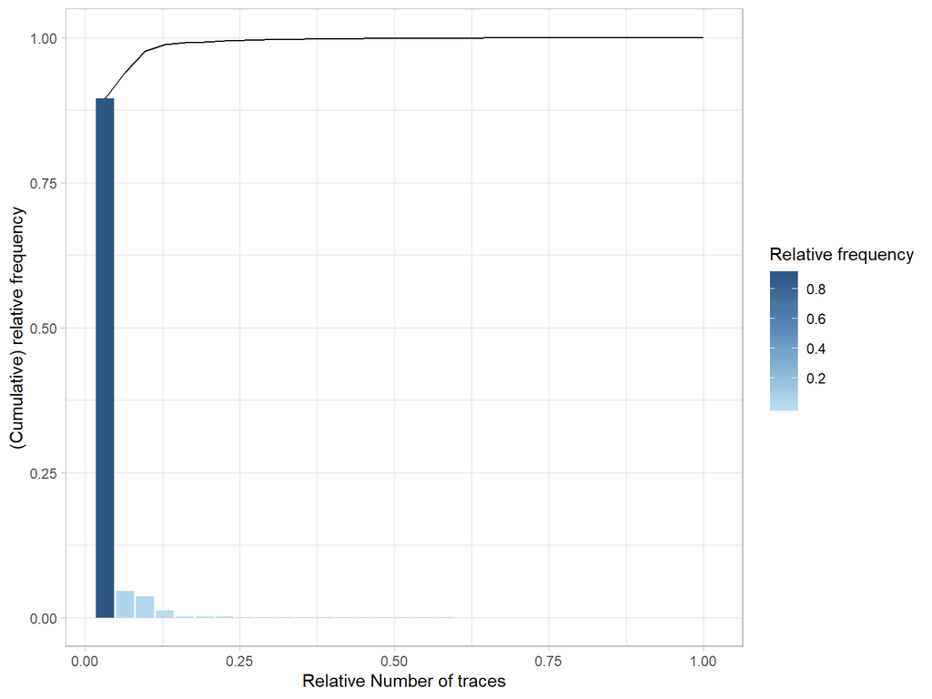

This is the trace

```
1. purchase
2. approve
3. deliver_carrier
4. deliver_customer
5. sent out review survey to customer
6. customer provides review
```

which occurs 21.583 times (or 89.5%) in the eventlog.

```r
traces <- traces(eventlog) %>% setDT()
traces[absolute_frequency == max(traces$absolute_frequency)]
```

[output not shown]

### c)

#### Process Explorarion

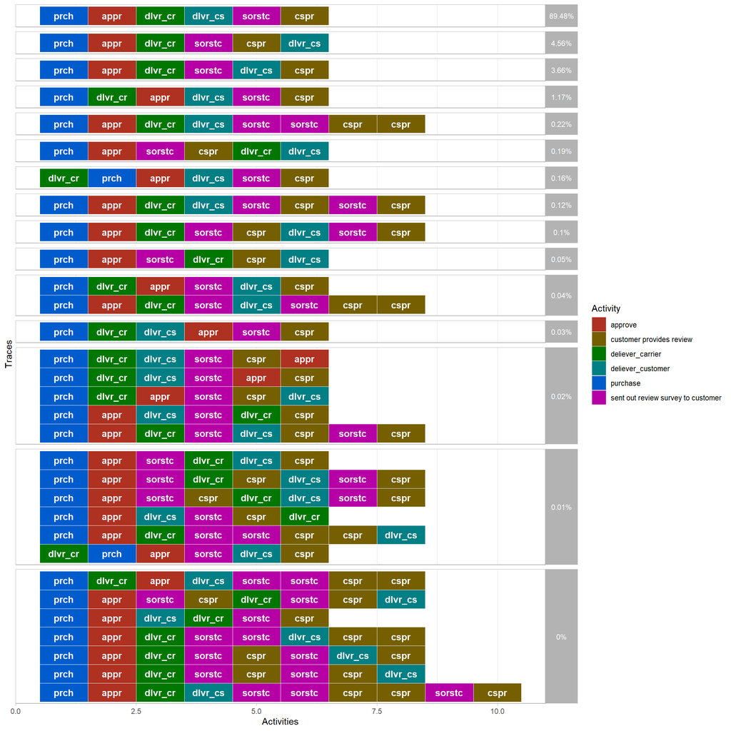

```r
eventlog %>% trace_explorer(coverage = 1)
```

#### Process map

```r
eventlog %>% process_map()
```

[interactive chart not shown]

#### d)

The most frequent variant occurs 21.583 times in the eventlog. It takes up 89.5% of all cases. (see b))

#### e)

The traces are on average 6.01 activities long. (See `summary()`)

The shortest trace contains 6 activities. The longest one 10. (see Figure for Exercise 2.c))

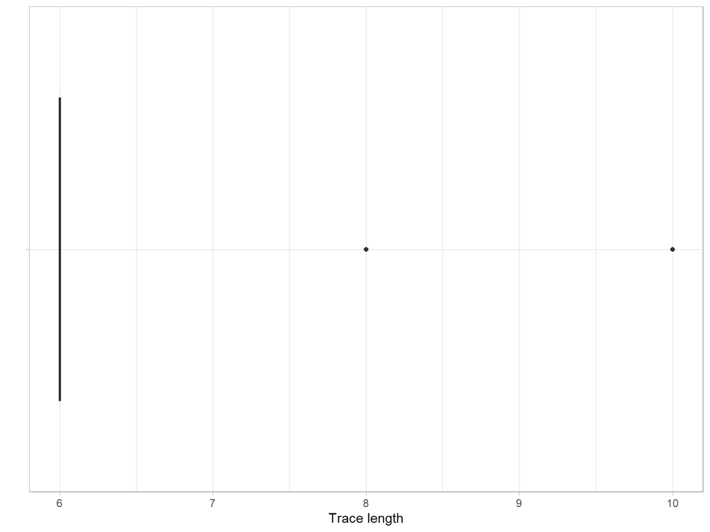

```r
eventlog %>% trace_length("log") %>%  plot
```

#### f)

Looking at the `process_map` and the `trace_explorer`, we can see that most cases start with `purchase`-activity, and most cases end with `customer provides survey`.

#### g)

The second and third most frequent variant (making up 4.56% and 3.66% of all cases respectively), deviate from the most frequent variant in terms of ordering of the activities:

- In the most frequent varianet, the (1) order is delivered, then (2) the survey is sent and then (3) the customer provides a review
- In the 2nd most frequent variant, (2) the survey is sent, (3) the customer provides the review, and (1) the order is delivered to the customer
- in the 3rd most frequent variant, the (2) surve is sent, then the (1) order is delivered and then (3) the customer provides a review.

## 3 Performance/Time Perspective

#### a)

The **throughput time** is defined a sthe time between the first event of a case and the very last.

- the mean throughput time is 15.95 days.
- the max. throughput time is 522 days
- the min. throughput time is 2.1 days

```r
eventlog %>% throughput_time("log")
```

[output not shown]

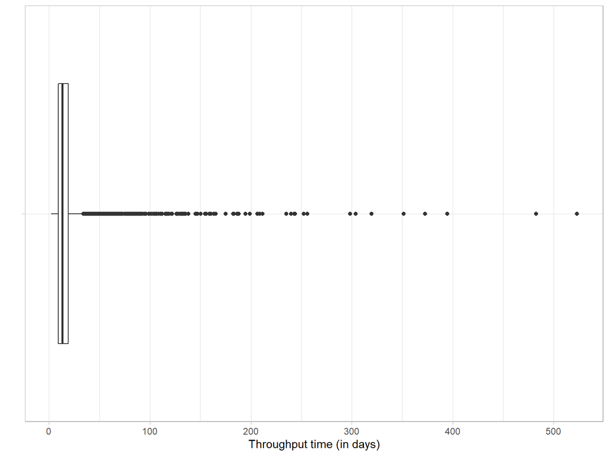

```r
eventlog %>% throughput_time("log", units = "days") %>% plot()
```

#### b)

```r
eventlog %>% process_map(performance(mean, "days"))
```

[interactive chart not shown]

Let $G=(V,E)$ with $V=\{v_1, \dots, v_N\}$ describe the directed graph in the figure. Then, each edge $e_i=(v_i,v_j)$ with $i,j \in \{1,...,N\}$, $i\neq j$ in $G$ is interpreted as follows: The weight of the edge tells you average time passed between the activity $v_i$ and activity $v_j$.

For example, on average, the transition from activity `purchase` to activity `approve` took 0.4 days.

#### c)

In a **dotted graph**, each point corresponds to a single activity. A single case is represented by its dots, which are horizontally aligned. The x-axis represents the timestamp of the activity; the y-axis represents the case. The cases are sorted according to their *starting time*.

- First of all, we note that the horizontal spread of each case hasn’t changed much over the years. This indicates that from start to finish, a single case still takes up the same absolute duration.
- The curvature of in the graph indicates that as the firm ages, more cases are initiated in the same fixed time interval.

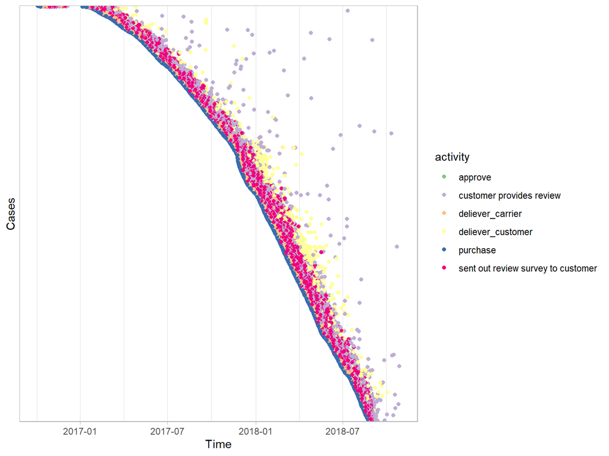

```r
eventlog %>% dotted_chart(x = "absolute", sort = "start")
```

## 4 Satisfaction Analysis

Here, variables that yield information on the duration between individual activities would be of interest:

- the duration between the purchase and approval
- the duration between approval and delivery
- the duration between the purchase and delivery
- the duration between the product delivered and review provided (maybe mad customers provide reviews quicker?)

```r
# A function that takes in an eventlog-dataset and creates a column with the
# duration (in hours) between the two specified activities.
CreateDurationVariable <- function(dat, fromActivity, toActivity, colname){
  data <- copy(dat)

  data[, fromActivityTimestamp := min(timestamp), by = .(order_id)]
  data[activity == fromActivity, fromActivityTimestamp := timestamp, by = .(order_id)]
  data[, fromActivityTimestamp := max(fromActivityTimestamp), by = .(order_id)]

  data[, toActivityTimestamp := min(timestamp), by = .(order_id)]
  data[activity == toActivity, toActivityTimestamp := timestamp, by = .(order_id)]
  data[, toActivityTimestamp := max(toActivityTimestamp), by = .(order_id)]

  data[, newDurationVariable := rep(0, length.out = nrow(data))]
  data[, newDurationVariable := as.numeric(
    difftime(toActivityTimestamp, fromActivityTimestamp, units = "days"))]

  data[, ':='(fromActivityTimestamp = NULL,
              toActivityTimestamp = NULL)]

  setnames(data, old="newDurationVariable", new=colname)
  return(data)
}
```

```r
dataRegression <- as.data.table(eventlog)
dataRegression[, activity := as.character(activity)]


# Create variable for the duration between purchase and delivery (to customer)
dataRegression <- CreateDurationVariable(
  dat = dataRegression,
  fromActivity = "purchase",
  toActivity = "deliever_customer",
  colname = "durPurchaseToDelivery"
)

# Create variable for the duration between purchase and approval
dataRegression <- CreateDurationVariable(
  dat = dataRegression,
  fromActivity = "purchase",
  toActivity = "approve",
  colname = "durPurchaseToApproval"
)

# Create variable for the duration between approval and delivery
dataRegression <- CreateDurationVariable(
  dat = dataRegression,
  fromActivity = "approve",
  toActivity = "deliever_customer",
  colname = "durApprovalToDelivery"
)

# Create variable for the duration between approval and delivery
dataRegression <- CreateDurationVariable(
  dat = dataRegression,
  fromActivity = "deliever_customer",
  toActivity = "customer provides review",
  colname = "durDeliveryToReview"
)
```

```r
# Remove variables that are non-relevant for regression
dataRegression <- dataRegression %>%
  select(-starts_with("max"),
         -ends_with("date"),
         -c("activity_instance",
            "status",
            "timestamp",
            ".order",
            "activity",
            "customer_state")) %>%
  setDT()

# Retain a single row for each case (Before, for each order there were several rows)
dataRegression <- dataRegression[!duplicated(dataRegression$order_id)]

# Further remove non-relevant variables
dataRegression <- dataRegression %>% select(-ends_with("id"))
```

```r
simpleLinearModel <- lm(review_score ~ ., dataRegression)
summary(simpleLinearModel)
```

```
##
## Call:
## lm(formula = review_score ~ ., data = dataRegression)
##
## Residuals:
##     Min      1Q  Median      3Q     Max
## -3.8823 -0.4371  0.4832  0.7396  9.0960
##
## Coefficients: (3 not defined because of singularities)
##                         Estimate Std. Error t value Pr(>|t|)
## (Intercept)            6.132e+00  1.263e-01  48.550  < 2e-16 ***
## boleto                 5.471e-02  6.738e-02   0.812   0.4168
## credit_card           -1.808e-02  6.506e-02  -0.278   0.7811
## debit_card            -4.939e-02  9.002e-02  -0.549   0.5833
## nmb_pay_types          3.098e-02  5.360e-02   0.578   0.5632
## not_defined                   NA         NA      NA       NA
## total_installments     4.643e-03  3.293e-03   1.410   0.1585
## total_pay_value        1.927e-03  4.587e-04   4.201 2.67e-05 ***
## voucher                       NA         NA      NA       NA
## nmb_items             -2.678e-01  1.836e-02 -14.587  < 2e-16 ***
## unique_items          -3.671e-03  4.722e-02  -0.078   0.9380
## nmb_sellers           -9.449e-01  8.906e-02 -10.609  < 2e-16 ***
## sum_items_value       -1.997e-03  4.769e-04  -4.186 2.85e-05 ***
## nmb_categories        -2.351e-01  1.122e-01  -2.096   0.0361 *
## avg_desc_length        3.053e-05  1.227e-05   2.488   0.0128 *
## avg_ph_quality        -3.783e-03  4.541e-03  -0.833   0.4048
## durPurchaseToDelivery -4.528e-02  8.717e-04 -51.947  < 2e-16 ***
## durPurchaseToApproval  3.014e-03  1.065e-02   0.283   0.7772
## durApprovalToDelivery         NA         NA      NA       NA
## durDeliveryToReview    1.295e-03  7.066e-04   1.833   0.0669 .
## ---
## Signif. codes:  0 '***' 0.001 '**' 0.01 '*' 0.05 '.' 0.1 ' ' 1
##
## Residual standard error: 1.197 on 23738 degrees of freedom
##   (365 observations deleted due to missingness)
## Multiple R-squared:  0.1324, Adjusted R-squared:  0.1318
## F-statistic: 226.3 on 16 and 23738 DF,  p-value: < 2.2e-16
```